# Data Visualization with R

- About this course
- Acknowledgements
- Introduction to Graphics
- Base ggplot2
- Creating a Scatter Plot
- Creating a Line Plot
- Creating a Bar Plot
- Creating a Histogram
- Creating a Box Plot
- Creating a Surface Plot
- Advanced ggplot2
- More on axes
- More on legend
- More on facet
- More on the overall appearance of plot
- More on Plots
- Presenting Plots

# More on scales customization

```r
require(ggplot2)
require(qdata)
data(bands)
```

Scales control the mapping from data to aestethics. The take your data and turn into something that you can see like colour, shape, position or size. Scales provide also the tools that allow you to read the plot: legends and axes.

## Scales scheme

A scale is required for every aestethic used on a plot. For example, when you write:

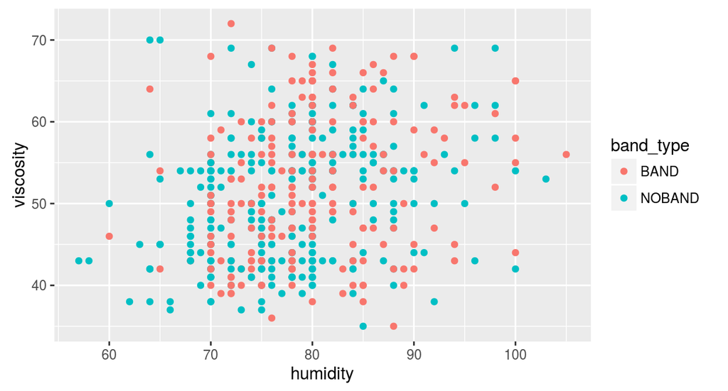

```r
ggplot(data=bands, mapping=aes(x=humidity, y=viscosity)) +
  geom_point(mapping = aes(colour=band_type))
```

What actually happens is:

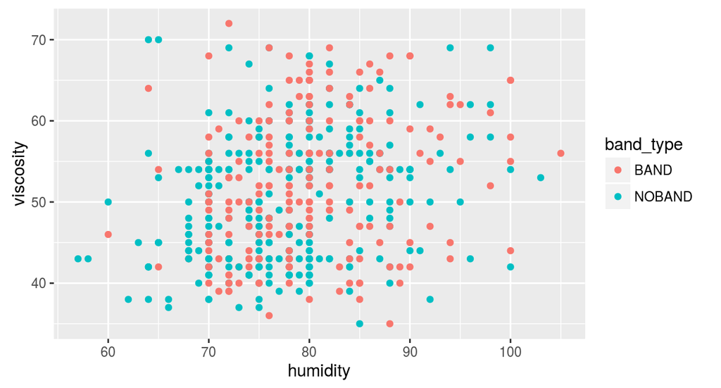

```r
ggplot(data=bands, mapping=aes(x=humidity, y=viscosity)) +
  geom_point(mapping = aes(colour=band_type)) +
  scale_x_continuous() +
  scale_y_continuous() +
  scale_color_discrete()
```

Default scales are named according to the aesthetic and the variable type. It would be tedious to manually add a scale every time a new aestethic is added, so `ggplot2` does it for you.

Note: the previous two specifications are equal.

Each scale has default values for its argument, this means that if you want to modify one or more feature of this scale you have to overwrite it/s default value. To overwrite its default value/s you have to manually add that scale.

For example, let us suppose that you want to increase the luminance of the points colours in the plot. Colour aesthetic mapping is controlled by `scale_color_discrete()` and the argument of `scale_color_discrete()` that control the luminance is `l`. `l` can assume values from 0 to 100 and its default value is 65. We modify the luminance in this way:

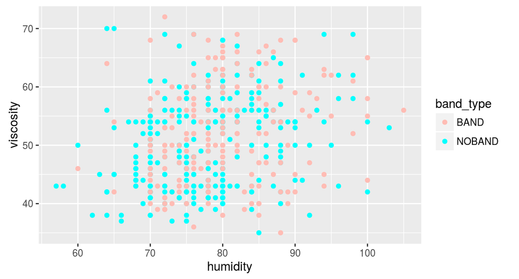

```r
ggplot(data=bands, mapping=aes(x=humidity, y=viscosity)) +
  geom_point(mapping = aes(colour=band_type)) +
  scale_color_discrete(l = 90)
```

The use of `+` to “add” a scale is a little misleading. Remember that when you `+` a scale you are not adding it but ovverwriting it.

### Scales naming scheme

The name for scaling scheme is made up by three pieces separated by `_`:

1. `scale`
2. the name of the aestethic (e.g., `colour`, `shape`, …)
3. the name of the scale (e.g., `continuous`, `discrete`, `brewer`, …)

## Scales family

Scales can be divided roughtly in four families:

1. Continuous position scale, used to map data into `x` and `y` position
2. Colour scales, used to map continuous and discrete data to colours
3. Manual scales, used to map discrete variables to your choice of size, linetype, shape or colour
4. Identity scale, used to plot avriables without scaling them